# Lab 3: Hip-Hop Lyrics

Author

Antonio da Silva

```r
library(tidyverse)
library(here)
library(dplyr)
```

## Summary

1. Provide a brief overview (2-4 sentences) of the dataset. (It is always good practice to start an analysis by getting a feel for the data and providing a quick summary for readers.) You do **not** need to show any source code for this question, although you probably want to use code to get some information about the dataset.

*It is a dataset that shows certain qualities of each person of their identity and musician’s qualities.This study is conducted by a linguist at University of Minnesota. There are 168 subjects with 64 different AAE terms. The score is quantified by how well the subject knows the term on a 1-5 scale.*

```r
hiphop <- read_csv(here::here("Week 3", "Lab 3", "hiphop.csv"))
```

2. What are the rows of this dataset? It is **not** one person per row!

3. Missing values for some of the variables were replaced with other values. How were missing values replaced? What do you believe are some benefits and drawbacks of doing this?

*Missing values were replaced with the mean of the variable. A drawback of keeping missing data is that not all rows will contribute to the analysis. A benefit of not having missing data is that you can include all of the dataset. Making the missing data the mean values can skew the data so that it is not actual data but actually manipulated data.*

**4.** Clean the dataset in whichever ways you see fit. This might mean adjusting *variable type*, for example from `character` to `factor`, or dealing with missing data.

```r
hiphop1 <- hiphop |>
  mutate(
    age = as.factor(age)
)
```

**5.** How many unique AAE words were studied in this dataset?

Helpful functions: `distinct()`, `count()`

```r
hiphop1 |>
  distinct(word) |>
  nrow()
```

```
[1] 64
```

**6.** Make a new variable that re-categorizes `ethnic` into only two groups, “white” and “non-white”, to simplify your data.

Helpful functions: `mutate()`, `if_else()`

```r
hiphop1 <- mutate(hiphop1,
                  ethnic = if_else(ethnic == "white", "white", "non-white"))
```

**7.** What are the demographics of the people in this study? Investigate the variables `sex`, `age`, and `ethnic` and summarize your findings in 1-3 complete sentences.

```r
hiphop1 |>
  mutate(sex = as.factor(sex),
         ethnic = as.factor(ethnic)) |>
  distinct(subj, sex, age, ethnic) |>
  summary()
```

```
     subj               sex           age           ethnic
 Length:168         Female:117   18     :69   non-white: 33
 Class :character   Male  : 51   19     :35   white    :135
 Mode  :character                20     :16
                                 21     :13
                                 17     :11
                                 22     : 5
                                 (Other):19
```

The demographics of this data shows that there are a majority of Female participants at 117 with only 51 Male participants. The age of the participants are mostly from 18-21 which makes me believe that it is in a college setting. Finally, the ethnicity of the participants are mostly white covering 135 participants while non-white participants are only 33.

**8.** Make at least two plots to display the demographic information of the subjects in this study. You do not need to discuss these plots, but make sure they are appropriate to the data types and have informative titles and axis labels. Feel free to use the skills you learned in Challenge 3 to enhance your plots!

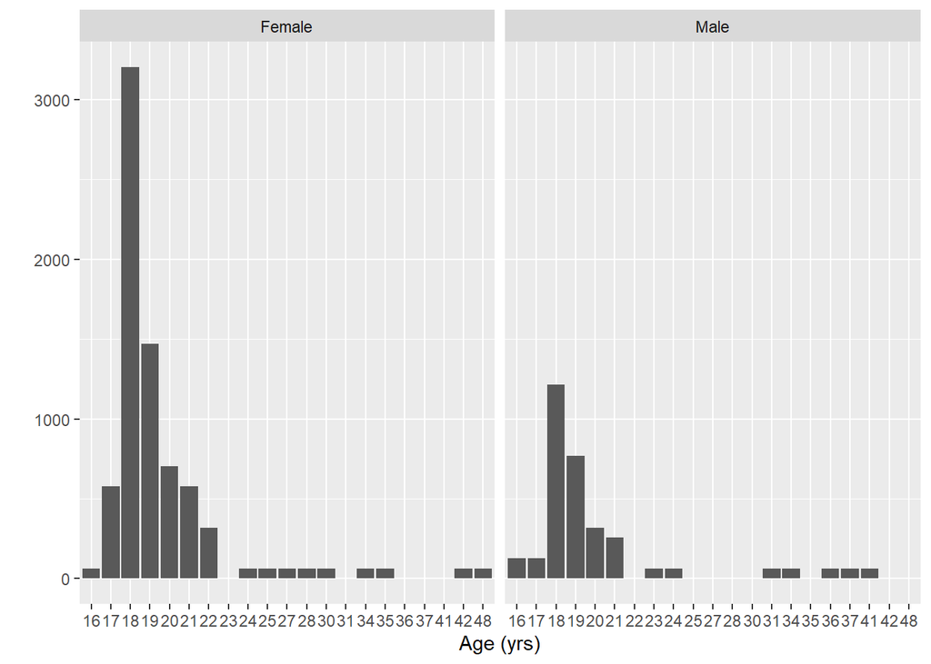

```r
library(ggplot2)
age = hiphop1$age
ggplot(data = hiphop1, mapping = aes(x = age)) +
  geom_bar() +
  labs(x = "Age (yrs)", y = "")  +
  facet_wrap(~sex)
```

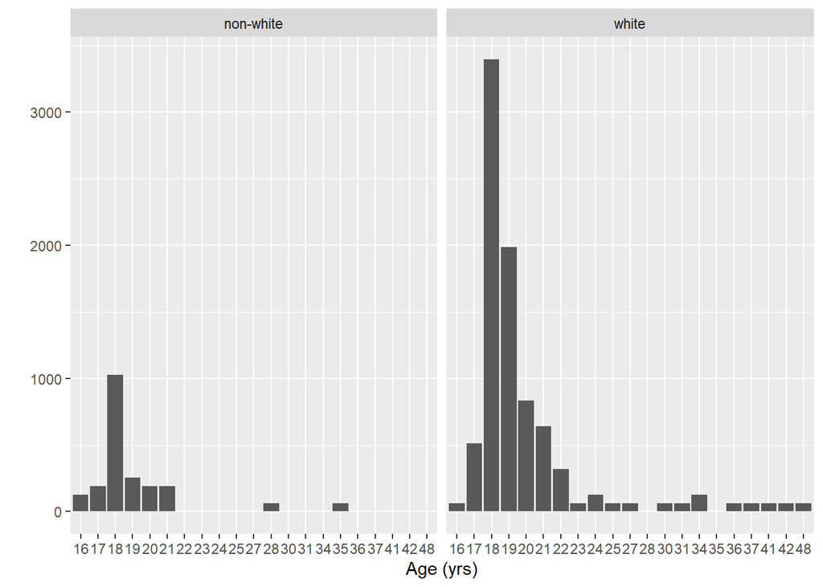

```r
ggplot(data = hiphop1, mapping = aes(x = age)) +
  geom_bar() +
  labs(x = "Age (yrs)", y = "")  +
  facet_wrap(~ethnic)
```

### **Familiar words**

For each demographic group listed below, determine which word(s) in this study was(were) the most **and** least familiar on average.

1. People below the age of 20
2. Non-white women
3. White men above the age of 30

Helpful functions: `filter()`, `group_by()`, `summarize()`, `slice_max()`, `slice_min()`

a.

```r
hiphop1 |>
  mutate(age = as.integer(age),
         word = as.factor(word)) |>
  filter(age < 20)  |>
  group_by(word) |>
  summarise(familiarity_avg = mean(familiarity)) |>
  slice_max(familiarity_avg, n = 1)
```

```
# A tibble: 1 × 2
  word         familiarity_avg
  <fct>                  <dbl>
1 off the hook            4.31
```

```r
hiphop1 |>
  mutate(age = as.integer(age),
         word = as.factor(word)) |>
  filter(age < 20)  |>
  group_by(word) |>
  summarise(familiarity_avg = mean(familiarity)) |>
  slice_min(familiarity_avg, n = 1)
```

```
# A tibble: 1 × 2
  word   familiarity_avg
  <fct>            <dbl>
1 domino            1.02
```

b.

```r
hiphop1 |>
  select(word, sex, ethnic, familiarity) |>
  filter(ethnic == "non-white",
         sex == "Female") |>
  group_by(word) |>
  summarise(familiarity_avg = mean(familiarity)) |>
  slice_max(familiarity_avg, n = 1)
```

```
# A tibble: 1 × 2
  word    familiarity_avg
  <chr>             <dbl>
1 feel me            4.19
```

```r
hiphop1 |>
  select(word, sex, ethnic, familiarity) |>
  filter(ethnic == "non-white",
         sex == "Female") |>
  group_by(word) |>
  summarise(familiarity_avg = mean(familiarity)) |>
  slice_min(familiarity_avg, n = 1)
```

```
# A tibble: 4 × 2
  word              familiarity_avg
  <chr>                       <dbl>
1 break someone out               1
2 dukey rope                      1
3 plex                            1
4 rollie                          1
```

c.

```r
above30 <- hiphop1 |>
  select(word, ethnic, sex, age, familiarity) |>
  mutate(age = as.numeric(age)) |>
  filter(ethnic == "white",
         sex == "Male",
         age > 30) |>
  group_by(word) |>
  summarise(familiarity_avg = mean(familiarity))

above30 |>
  slice_max(familiarity_avg, n = 1)
```

```
# A tibble: 0 × 2
# … with 2 variables: word <chr>, familiarity_avg <dbl>
```

```r
above30 |>
  slice_min(familiarity_avg, n = 1)
```

```
# A tibble: 0 × 2
# … with 2 variables: word <chr>, familiarity_avg <dbl>
```

### **Study Subjects**

A joke among the [Tidy Tuesday](https://www.tidytuesday.com/) community is that Justin Bieber was one of the subjects in this study. Bieber, a white male, from a relatively small town (10,000-60,000 people) in Ontario would have been 17-23 at the time of the study.

Determine which subject you believe is secretly Bieber, justify your answer. *Hint: Refer again to the dataset description. There is another clue about Bieber’s identity.*

```r
hiphop1 |>
  select(subj, sex, ethnic, age, city, bieber) |>
  mutate(age = as.integer(age),
         ethnic = as.factor(ethnic)) |>
  filter(sex == 'Male',
         ethnic == 'white',
         city > 10000,
         city < 60000,
         age <= 23,
         age >= 17)  |>
  slice_max(bieber, n=1) |>
  group_by(subj) |>
  summarise()
```

```
# A tibble: 1 × 1
  subj
  <chr>
1 p38
```